# EasyVisa_Full_Code_Notebook_Final (1)

#### Does visa certification depend on when a company was established?

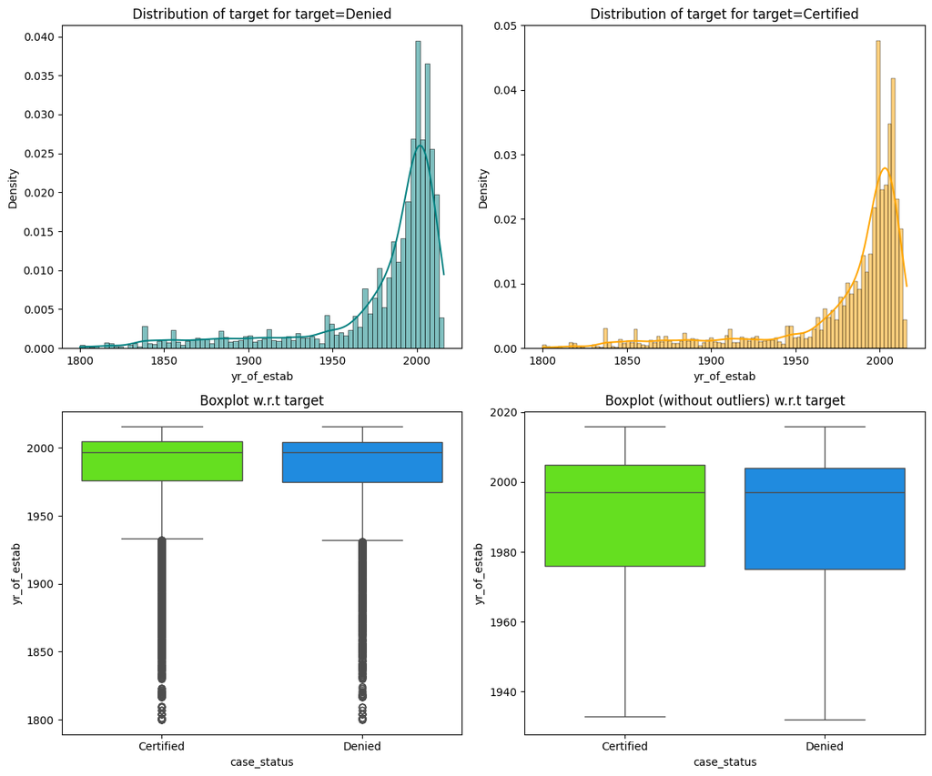

```python
# Observe the distribution of year of establishment for each case status
distribution_plot_wrt_target(data, 'yr_of_estab', 'case_status')
```

- Age of the company doesn't seem to contribute too much towards the chances for visa certification

#### Heatmap

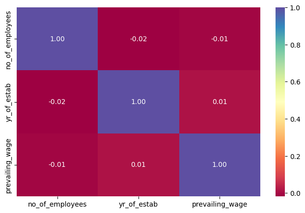

```python
# Generate a heatmap for the numeric columns
cols_list = data.select_dtypes(include=np.number).columns.tolist()

plt.figure(figsize=(8, 5))
sns.heatmap(data[cols_list].corr(), annot=True, fmt=".2f", cmap="Spectral"
)
plt.show()
```

- There is no correlation between any of the numeric columns

## Data Pre-processing

### Outlier Check

```python
# Identify lower and upper quantiles for the continuous columns
Q1 = data[['no_of_employees', 'yr_of_estab', 'prevailing_wage']].quantile(.25)
Q3 = data[['no_of_employees', 'yr_of_estab', 'prevailing_wage']].quantile(.75)

# Calculate the IQR
IQR = Q3-Q1

# Identify the lower bound and upper bound to check for outliers
lower_bound = Q1 - (1.5*IQR)
upper_bound = Q3 + (1.5*IQR)

# Calculate the outlier percentages for each continuous columns
((data[['no_of_employees', 'yr_of_estab', 'prevailing_wage']] < lower_bound) | (data[['no_of_employees', 'yr_of_estab', 'prevailing_wage']] > upper_bound)).sum()/len(data)*100
```

|  | 0 |
| --- | --- |
| no_of_employees | 6.106750 |
| yr_of_estab | 12.794349 |
| prevailing_wage | 1.675824 |

**dtype:** float64

- Outliers were observed in the numeric columns during Univariate analysis
- no_of_employees has outliers in about 6.1% of the records
- yr_of_estab has outliers in about 12.8% of the records
- prevailing_wage has outliers in about 1.7% of the records
- Decision Trees and other models using decision trees are less prone to outliers for classification problems, and hence we will not perform any outlier treatment

### Data Preparation for modeling

- Prevailing wage has been given in multiple units - Yearly, Monthly, Weekly and Hourly
- It has to be converted into a standardized unit.
- We will convert the weekly and monthly wages to yearly wage as 52 weeks constitute a year, and 12 months constitute a year
- We will not convert hourly wage into yearly wage, as we do not know how many hours will the candidates work in a year

```python
# Specify the conditions where prevailing wage has to be changed
conditions = [
    data['unit_of_wage'] == 'Hour',
    data['unit_of_wage'] == 'Week',
    data['unit_of_wage'] == 'Month',
    data['unit_of_wage'] == 'Year'
]

# Specify the calculation to convert the wage to yearly wage
choices = [
    data['prevailing_wage'],
    data['prevailing_wage'] * 52,
    data['prevailing_wage'] * 12,
    data['prevailing_wage']
]

# Convert weekly and montly wages to yearly wages
data['prevailing_wage'] = np.select(conditions, choices)
```

Change the columns having Y/N indicators to 1/0 values

```python
# Change Y/N to 1/0 for the columns case_status, has_job_experience, requires_job_training and full_time_position
data['case_status'] = data['case_status'].apply(lambda x: 1 if x == 'Certified' else 0)
data['has_job_experience'] = data['has_job_experience'].apply(lambda x: 1 if x == 'Y' else 0)
data['requires_job_training'] = data['requires_job_training'].apply(lambda x: 1 if x == 'Y' else 0)
data['full_time_position'] = data['full_time_position'].apply(lambda x: 1 if x == 'Y' else 0)
```

Education of employee should be encoded with ordinal values

```python
# Perform ordinal encoding of education_of_employee, with High School being the lowest, followed by Bachelor's, Master's and Doctorate
# Define the map to apply the ordinal values
education_map = {"High School": 1, "Bachelor's": 2, "Master's": 3, "Doctorate": 4}
data['education_of_employee'] = data['education_of_employee'].map(education_map)
```

Calculate the age of the company, using 2016 as the base year as the data has been given from the year 2016

```python
# Calculate the age of the company
data['company_age'] = 2016-data['yr_of_estab']
```

Categorize the size of the company based on the number of employees in the company

```python
# Categorize company size based on the number of employees
bins = [0, 1000, 2000, 3000, 1000000]
labels = ['Small', 'Medium', 'Large', 'Very Large'] # or use descriptive labels like 'Small', 'Medium', 'Large', 'Very Large'

# Create binned feature in training data
data['company_size'] = pd.cut(data['no_of_employees'], bins=bins, labels=labels, include_lowest=True)

display(data['company_size'].value_counts())
```

| company_size | count |
| --- | --- |
| Very Large | 8346 |
| Small | 6241 |
| Medium | 5915 |
| Large | 4978 |

**dtype:** int64

Convert categorical columns having numeric data to integer columns

```python
# Change data type of columns case_status, has_job_experience, requires_job_training, full_time_position and education_of_employee to integer
data[['case_status', 'has_job_experience', 'requires_job_training', 'full_time_position', 'education_of_employee']] = data[['case_status', 'has_job_experience', 'requires_job_training', 'full_time_position', 'education_of_employee']].astype("int64")
```

Create training, validation and test datasets

```python
# Drop yr_of_estab and no_of_employees columns from the training dataset as they have been transformed into new columns
x = data.drop(['case_status', 'yr_of_estab', 'no_of_employees'], axis=1)
y = data['case_status']

# Encode the categorical columns
x = pd.get_dummies(x, drop_first=True)

'''
Split the complete dataset into temporary and test data set, with about 10% of the data allocated to the test dataset
Temporary dataset will be further split into training and validation datasets
Test dataset will be used to measure the performance of the final model selected
'''
x_temp, x_test, y_temp, y_test = train_test_split(x, y, test_size=0.1, random_state=1, stratify=y)

'''
Split the temporary dataset into training and validation dataset with about 25% of the data allocated to the validation dataset
Models will be trained on the training dataset and will be tuned on basis of performance on the validation dataset
'''
x_train, x_val, y_train, y_val = train_test_split(x_temp, y_temp, test_size=0.25, random_state=1, stratify=y_temp)
```

```python
# Check the count of records in the all the 3 datasets

print('Shape of training set: ', x_train.shape)
print('Shape of validation set: ', x_val.shape)
print('Shape of test set: ', x_test.shape)

print('Percentage of classes in training set:')
print(y_train.value_counts(True))

print('Percentage of classes in validation set:')
print(y_val.value_counts(True))

print('Percentage of classes in test set:')
print(y_test.value_counts(True))
```

```
Shape of training set:  (17199, 21)
Shape of validation set:  (5733, 21)
Shape of test set:  (2548, 21)
Percentage of classes in training set:
case_status
1    0.667888
0    0.332112
Name: proportion, dtype: float64
Percentage of classes in validation set:
case_status
1    0.667888
0    0.332112
Name: proportion, dtype: float64
Percentage of classes in test set:
case_status
1    0.667975
0    0.332025
Name: proportion, dtype: float64
```

## Model Building

### Model Evaluation Criterion

**A model can make wrong predictions in the following ways:**

- Predicting a visa application will be certified, but in reality the application is deined (False Positive: Predicted - 1, Actual - 0)
- Predicting a visa application will be denied, but in reality the application is certified (False Negative: Predicted - 0, Actual - 1)

**What is important to the OFLC?**

- OFLC wants to shortlist the candidates having higher chances of Visa approval
- If we predict that the application will be certified, but if the application is actually not eligible for certification, below things could happen:
  - Unqaulified applicants could gain entry to work
  - Risk of misuse if someone intentionally exploits weaknesses in the system
  - If many unqualified applications are shortlisted, it will additional workload for the OFLC and will be waste of resources to further process those applications
  - It could lead to missing opportunities for genuienly qualified applicants
- If we predict that the application will be deined, but if the application is actually eligible for certification, below things could happen:
  - Qualified applicants may end up being wrongly deined
  - Employers may lose access to the skilled workers that they need, and the country can eventually lose out on the contirubtions to the economy
  - Wrongly denied applicants may end up reapplying, leading to additional costs and workload for the immigration authority

**How to identify as many eligibile applicants as possible while avoiding ineligible applications**

- The OFLC would want to identify as many eligible applicants as possible, while also wanting to reduce the risk of wrongly approving ineligible applications. In other words, the OFLC may want to keep the False Positives and False Negatives in balance.
- If there are too many False Positives or too many False Negatives, the visa system may seen as biased or unreliable
- To achieve this, F1 should be maximized so that both False Positives and False Negatives are kept in check

First, let's create functions to calculate different metrics and confusion matrix so that we don't have to use the same code repeatedly for each model.

- The `model_performance_classification_sklearn` function will be used to check the model performance of models.
- The `confusion_matrix_sklearn` function will be used to plot the confusion matrix.

```python
# defining a function to compute different metrics to check performance of a classification model built using sklearn


def model_performance_classification_sklearn(model, predictors, target):
    """
    Function to compute different metrics to check classification model performance

    model: classifier
    predictors: independent variables
    target: dependent variable
    """

    # predicting using the independent variables
    pred = model.predict(predictors)

    acc = accuracy_score(target, pred)  # to compute Accuracy
    recall = recall_score(target, pred)  # to compute Recall
    precision = precision_score(target, pred)  # to compute Precision
    f1 = f1_score(target, pred)  # to compute F1-score

    # creating a dataframe of metrics
    df_perf = pd.DataFrame(
        {"Accuracy": acc, "Recall": recall, "Precision": precision, "F1": f1,},
        index=[0],
    )

    return df_perf
```

```python
def confusion_matrix_sklearn(model, predictors, target):
    """
    To plot the confusion_matrix with percentages

    model: classifier
    predictors: independent variables
    target: dependent variable
    """
    y_pred = model.predict(predictors)
    cm = confusion_matrix(target, y_pred)
    labels = np.asarray(
        [
            ["{0:0.0f}".format(item) + "\n{0:.2%}".format(item / cm.flatten().sum())]
            for item in cm.flatten()
        ]
    ).reshape(2, 2)

    plt.figure(figsize=(6, 4))
    sns.heatmap(cm, annot=labels, fmt="")
    plt.ylabel("True label")
    plt.xlabel("Predicted label")
```

#### Defining scorer to be used for cross-validation and hyperparameter tuning

```python
# Define a scorer with f1_score as the mteric to evaludate
scorer = metrics.make_scorer(metrics.f1_score)
```

**We are now done with pre-processing and evaluation criterion, so let's start building the model.**

### Model building with Original data

```python
# Define all the base models
models = []
models.append(("DTree", DecisionTreeClassifier(random_state=1)))
models.append(("Bagging", BaggingClassifier(random_state=1)))
models.append(("RandomForest", RandomForestClassifier(random_state=1)))
models.append(("AdaBoost", AdaBoostClassifier(random_state=1)))
models.append(("GradientBoost", GradientBoostingClassifier(random_state=1)))
models.append(("XGBoost", XGBClassifier(random_state=1)))

names = []

# Define a cross validation strategy with 10 splits for the training data
kfold = StratifiedKFold(n_splits=10, shuffle=True, random_state=1)


# For all the base models defined, evaluate the cross validation scores by using the training data, and using f1_score as the evaluation metric
for name, model in models:
    cv_result = cross_val_score(estimator=model, X=x_train, y=y_train, scoring=scorer, cv=kfold)
    names.append(name)
    print("{}: {}".format(name, cv_result.mean()))
```

```
DTree: 0.7433057596269588
Bagging: 0.772809454002332
RandomForest: 0.7893486922322435
AdaBoost: 0.8171369101284816
GradientBoost: 0.8233232979076925
XGBoost: 0.8103670612380686
```

```python
'''
Evaluate the performance of all the models on the training and validation datasets
Store the performance metrics in dataframes
'''

model_original_data_train_perf = pd.DataFrame()
model_original_data_val_perf = pd.DataFrame()
for name, model in models:
    model.fit(x_train, y_train)

    model_performance = model_performance_classification_sklearn(model, x_train, y_train)
    model_original_data_train_perf = pd.concat([model_original_data_train_perf, model_performance])

    model_performance = model_performance_classification_sklearn(model, x_val, y_val)
    model_original_data_val_perf = pd.concat([model_original_data_val_perf, model_performance])

model_original_data_train_perf.index = model_original_data_val_perf.index = names
```

```python
# Observe the performance on training dataset
model_original_data_train_perf.T
```

|  | DTree | Bagging | RandomForest | AdaBoost | GradientBoost | XGBoost |
| --- | --- | --- | --- | --- | --- | --- |
| Accuracy | 1.0 | 0.984999 | 1.0 | 0.737543 | 0.756614 | 0.822432 |
| Recall | 1.0 | 0.986071 | 1.0 | 0.883085 | 0.879168 | 0.920084 |
| Precision | 1.0 | 0.991422 | 1.0 | 0.761848 | 0.783050 | 0.831877 |
| F1 | 1.0 | 0.988740 | 1.0 | 0.817999 | 0.828330 | 0.873760 |

```python
# Observe the performance on validation dataset
model_original_data_val_perf.T
```

|  | DTree | Bagging | RandomForest | AdaBoost | GradientBoost | XGBoost |
| --- | --- | --- | --- | --- | --- | --- |
| Accuracy | 0.659341 | 0.690738 | 0.716204 | 0.739752 | 0.750044 | 0.737485 |
| Recall | 0.736746 | 0.776704 | 0.829982 | 0.881954 | 0.872552 | 0.858971 |
| Precision | 0.749071 | 0.764132 | 0.765046 | 0.764546 | 0.779515 | 0.773155 |
| F1 | 0.742857 | 0.770367 | 0.796192 | 0.819064 | 0.823413 | 0.813807 |

- GradientBoost model has the best F1 score on the validation dataset across all models
- AdaBoost model has the next best F1 score on the validation dataset
- Decision Tree model has the least F1 score on the validation dataset of all the models
- GradientBoost and AdaBoost models appear to be generalizing well as all the scores between the training and validation dataset are very close for these models

### Model Building with Oversampled data

```python
'''
Perform oversampling on the training data using SMOTE
Mutliple values of sampling_strategy were tried. sampling_strategy of a value lower than 1 was giving better performance than a value of 1,
and hence a value of 0.7 has been used
'''
smote = SMOTE(sampling_strategy=0.7, k_neighbors=5, random_state=1)
x_train_over, y_train_over = smote.fit_resample(x_train, y_train)

print('Count of records for class 1 in original training data: ', sum(y_train == 1))
print('Count of records for class 1 in oversampled training data: ', sum(y_train_over == 1))
print()
print('Count of records for class 0 in original training data: ', sum(y_train == 0))
print('Count of records for class 0 in oversampled training data: ', sum(y_train_over == 0))
```

```
Count of records for class 1 in original training data:  11487
Count of records for class 1 in oversampled training data:  11487

Count of records for class 0 in original training data:  5712
Count of records for class 0 in oversampled training data:  8040
```

```python
# Define all the base models
models_oversample = []
models_oversample.append(("DTree", DecisionTreeClassifier(random_state=1)))
models_oversample.append(("Bagging", BaggingClassifier(random_state=1)))
models_oversample.append(("RandomForest", RandomForestClassifier(random_state=1)))
models_oversample.append(("AdaBoost", AdaBoostClassifier(random_state=1)))
models_oversample.append(("GradientBoost", GradientBoostingClassifier(random_state=1)))
models_oversample.append(("XGBoost", XGBClassifier(random_state=1)))


# Define a cross validation strategy with 10 splits for the oversampled training data
kfold = StratifiedKFold(n_splits=10, shuffle=True, random_state=1)

# For all the base models defined, evaluate the cross validation scores by using the oversampled training data, and using f1_score as the evaluation metric
for name, model in models_oversample:
    cv_result = cross_val_score(estimator=model, X=x_train_over, y=y_train_over, scoring=scorer, cv=kfold)

    print("{}: {}".format(name, cv_result.mean()))
```

```
DTree: 0.7357787408018697
Bagging: 0.763587953838107
RandomForest: 0.787982161354642
AdaBoost: 0.7998084252362785
GradientBoost: 0.8160730938010328
XGBoost: 0.8064637257776148
```

```python
'''
Evaluate the performance of all the models on the oversampled training dataset and original validation dataset
Store the performance metrics in dataframes
'''
scores = []
model_oversample_data_train_perf = pd.DataFrame()
model_oversample_data_val_perf = pd.DataFrame()
for name, model in models_oversample:
    model.fit(x_train_over, y_train_over)

    model_performance = model_performance_classification_sklearn(model, x_train_over, y_train_over)
    model_oversample_data_train_perf = pd.concat([model_oversample_data_train_perf, model_performance])

    model_performance = model_performance_classification_sklearn(model, x_val, y_val)
    model_oversample_data_val_perf = pd.concat([model_oversample_data_val_perf, model_performance])


model_oversample_data_train_perf.index = model_oversample_data_val_perf.index = names
```

```python
# Observe the performance on the oversampled training dataset
model_oversample_data_train_perf.T
```

|  | DTree | Bagging | RandomForest | AdaBoost | GradientBoost | XGBoost |
| --- | --- | --- | --- | --- | --- | --- |
| Accuracy | 1.0 | 0.984534 | 1.0 | 0.752394 | 0.775644 | 0.834895 |
| Recall | 1.0 | 0.982502 | 1.0 | 0.845739 | 0.869156 | 0.909115 |
| Precision | 1.0 | 0.991130 | 1.0 | 0.760291 | 0.776240 | 0.827299 |
| F1 | 1.0 | 0.986797 | 1.0 | 0.800742 | 0.820075 | 0.866280 |

```python
# Observe the performance on validation dataset
model_oversample_data_val_perf.T
```

|  | DTree | Bagging | RandomForest | AdaBoost | GradientBoost | XGBoost |
| --- | --- | --- | --- | --- | --- | --- |
| Accuracy | 0.664574 | 0.693529 | 0.716902 | 0.732426 | 0.750916 | 0.742194 |
| Recall | 0.746931 | 0.762079 | 0.817446 | 0.845129 | 0.867328 | 0.857665 |
| Precision | 0.749869 | 0.775239 | 0.772077 | 0.774719 | 0.783070 | 0.778753 |
| F1 | 0.748397 | 0.768603 | 0.794114 | 0.808394 | 0.823048 | 0.816306 |

```python
# Observe the difference in the performance metrics on the validation dataset between the models trained on oversampled data and original data
model_oversample_data_val_perf.T - model_original_data_val_perf.T
```

|  | DTree | Bagging | RandomForest | AdaBoost | GradientBoost | XGBoost |
| --- | --- | --- | --- | --- | --- | --- |
| Accuracy | 0.005233 | 0.002791 | 0.000698 | -0.007326 | 0.000872 | 0.004710 |
| Recall | 0.010185 | -0.014625 | -0.012536 | -0.036824 | -0.005223 | -0.001306 |
| Precision | 0.000798 | 0.011108 | 0.007031 | 0.010173 | 0.003555 | 0.005598 |
| F1 | 0.005540 | -0.001764 | -0.002078 | -0.010670 | -0.000365 | 0.002499 |

- GradientBoost model has the best F1 score on the validation dataset across all models
- XGBoost model has the next best F1 score on the validation dataset
- Decision Tree model has the least F1 score on the validation dataset of all the models
- XGBoost and Decision Tree models trained on oversampled data has a slightly better performance than the models trained on original data, although the difference in the performance is very minimal
- Other models trained on original have a better performance compared to models trained on oversampled data, although the difference in the performance is very minimal

### Model Building with Undersampled data

```python
'''
Perform undersampling on the training data using RandomUnderSampler
Mutliple values of sampling_strategy were tried. sampling_strategy of a value lower than 1 was giving better performance than a value of 1,
and hence a value of 0.65 has been used
'''
rus = RandomUnderSampler(sampling_strategy=0.65, random_state=1)
x_train_under, y_train_under = rus.fit_resample(x_train, y_train)

print('Count of records for class 1 in original training data: ', sum(y_train == 1))
print('Count of records for class 1 in undersampled training data: ', sum(y_train_under == 1))
print()
print('Count of records for class 0 in original training data: ', sum(y_train == 0))
print('Count of records for class 0 in undersampled training data: ', sum(y_train_under == 0))
```

```
Count of records for class 1 in original training data:  11487
Count of records for class 1 in undersampled training data:  8787

Count of records for class 0 in original training data:  5712
Count of records for class 0 in undersampled training data:  5712
```

```python
# Define all the base models
models_undersample = []
models_undersample.append(("DTree", DecisionTreeClassifier(random_state=1)))
models_undersample.append(("Bagging", BaggingClassifier(random_state=1)))
models_undersample.append(("RandomForest", RandomForestClassifier(random_state=1)))
models_undersample.append(("AdaBoost", AdaBoostClassifier(random_state=1)))
models_undersample.append(("GradientBoost", GradientBoostingClassifier(random_state=1)))
models_undersample.append(("XGBoost", XGBClassifier(random_state=1)))

# Define a cross validation strategy with 10 splits for the undersampled training data
kfold = StratifiedKFold(n_splits=10, shuffle=True, random_state=1)

# For all the base models defined, evaluate the cross validation scores by using the undersampled training data, and using f1_score as the evaluation metric
for name, model in models_undersample:
    cv_result = cross_val_score(estimator=model, X=x_train_under, y=y_train_under, scoring=scorer, cv=kfold)

    print("{}: {}".format(name, cv_result.mean()))
```

```
DTree: 0.6985778363183208
Bagging: 0.7273762227800742
RandomForest: 0.7499352475817502
AdaBoost: 0.7826210378353002
GradientBoost: 0.7874557004004774
XGBoost: 0.7719156325437353
```

```python
'''
Evaluate the performance of all the models on the undersampled training and validation datasets
Store the performance metrics in dataframes
'''
model_undersample_data_train_perf = pd.DataFrame()
model_undersample_data_val_perf = pd.DataFrame()
for name, model in models_undersample:
    model.fit(x_train_under, y_train_under)

    model_performance = model_performance_classification_sklearn(model, x_train_under, y_train_under)
    model_undersample_data_train_perf = pd.concat([model_undersample_data_train_perf, model_performance])

    model_performance = model_performance_classification_sklearn(model, x_val, y_val)
    model_undersample_data_val_perf = pd.concat([model_undersample_data_val_perf, model_performance])

model_undersample_data_train_perf.index = model_undersample_data_val_perf.index = names
```

```python
# Observe the performance on undersampled training dataset
model_undersample_data_train_perf.T
```

|  | DTree | Bagging | RandomForest | AdaBoost | GradientBoost | XGBoost |
| --- | --- | --- | --- | --- | --- | --- |
| Accuracy | 1.0 | 0.982551 | 1.0 | 0.716187 | 0.738051 | 0.824540 |
| Recall | 1.0 | 0.979174 | 1.0 | 0.856606 | 0.843064 | 0.900990 |
| Precision | 1.0 | 0.991930 | 1.0 | 0.725005 | 0.753841 | 0.825461 |
| F1 | 1.0 | 0.985511 | 1.0 | 0.785330 | 0.795960 | 0.861574 |

```python
# Observe the performance on validation dataset
model_undersample_data_val_perf.T
```

|  | DTree | Bagging | RandomForest | AdaBoost | GradientBoost | XGBoost |
| --- | --- | --- | --- | --- | --- | --- |
| Accuracy | 0.650619 | 0.680621 | 0.702425 | 0.739055 | 0.748823 | 0.731380 |
| Recall | 0.704100 | 0.719770 | 0.773048 | 0.856098 | 0.835727 | 0.813267 |
| Precision | 0.756029 | 0.784291 | 0.779563 | 0.776225 | 0.797806 | 0.790556 |
| F1 | 0.729141 | 0.750647 | 0.776292 | 0.814208 | 0.816327 | 0.801751 |

```python
# Observe the difference in the performance metrics on the validation dataset between the models trained on oversampled data and original data
model_undersample_data_val_perf.T - model_original_data_val_perf.T
```

|  | DTree | Bagging | RandomForest | AdaBoost | GradientBoost | XGBoost |
| --- | --- | --- | --- | --- | --- | --- |
| Accuracy | -0.008721 | -0.010117 | -0.013780 | -0.000698 | -0.001221 | -0.006105 |
| Recall | -0.032646 | -0.056934 | -0.056934 | -0.025855 | -0.036824 | -0.045704 |
| Precision | 0.006959 | 0.020160 | 0.014517 | 0.011679 | 0.018291 | 0.017401 |
| F1 | -0.013716 | -0.019720 | -0.019900 | -0.004856 | -0.007087 | -0.012056 |

- All the models are giving better performance on original data compared to the performance on undersampled data

## Hyperparameter Tuning

Note: GridSearchCV does an exhaustive search across all the combinations of the hyperparameter values. The computation time while using GridSearchCV was very high and the tuning was taking very long. RandomizedSearchCV has been used to identify best hyperparameters

```python
# Plot the feature importance score for features in the model
def show_feature_importances(model, x_train):
    feature_names = x_train.columns
    importances = model.feature_importances_
    indices = np.argsort(importances)

    plt.figure(figsize=(12, 12))
    plt.title("Feature Importances")
    plt.barh(range(len(indices)), importances[indices], color="violet", align="center")
    plt.yticks(range(len(indices)), [feature_names[i] for i in indices])
    plt.xlabel("Relative Importance")
    plt.show()
```

#### Decision Tree model tuning

Decision Tree model was giving almost similar performance for the models using the original data and oversampled data. Let's tune the Decision Tree model using the original training data

```python
# Initialize the model
dtree_tuned = DecisionTreeClassifier(random_state=1)

# Define the parameter grid to identify the best model using RandomizedSearchCV
rcv_params = {'max_depth': np.arange(2, 11, 1),
              'max_leaf_nodes': [25, 50, 75, 100, 150, 200, 250],
              'min_samples_split': [5, 10, 20, 30, 40, 50],
             }

# Initialize the RandomizedSearchCV object while using F1 as the scoring method
# Use cv=5 to split the training data into 5 parts, and train and evaluate the model 5 times by using each part as validation set once each time
rcv = RandomizedSearchCV(dtree_tuned, rcv_params, n_iter=500, scoring=scorer, cv=5, random_state=1, n_jobs=-1, verbose=2)
rcv.fit(x_train, y_train)

print(rcv.best_params_)

dtree_tuned = rcv.best_estimator_
```

```
Fitting 5 folds for each of 378 candidates, totalling 1890 fits
{'min_samples_split': 5, 'max_leaf_nodes': 25, 'max_depth': np.int64(7)}
```

```python
# Get the model performance on the training data
dtree_train_perf = model_performance_classification_sklearn(dtree_tuned, x_train, y_train)
dtree_train_perf.index = ['DTree']
dtree_train_perf
```

|  | Accuracy | Recall | Precision | F1 |
| --- | --- | --- | --- | --- |
| DTree | 0.750974 | 0.875773 | 0.778879 | 0.824489 |

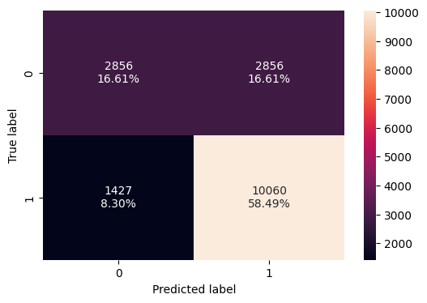

```python
# Plot the confusion matrix for the precitions on training dataset
confusion_matrix_sklearn(dtree_tuned, x_train, y_train)
```

```python
# Get the model performance on the test data
dtree_val_perf = model_performance_classification_sklearn(dtree_tuned, x_val, y_val)
dtree_val_perf.index = ['DTree']
dtree_val_perf
```

|  | Accuracy | Recall | Precision | F1 |
| --- | --- | --- | --- | --- |
| DTree | 0.750916 | 0.873335 | 0.780033 | 0.824051 |

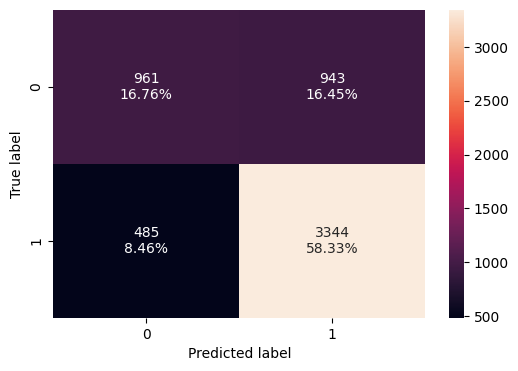

```python
# Plot the confusion matrix for the precitions on validation dataset
confusion_matrix_sklearn(dtree_tuned, x_val, y_val)
```

```python
# Compare the performance of the un-tuned decision tree and the tuned decision tree on the validation data
test_perf = pd.concat(
    [
        model_original_data_val_perf.loc[['DTree']].T,
        dtree_val_perf.T
    ],
    axis=1
)

test_perf.columns = ['DTree_Original', 'DTree_Tuned']

test_perf
```

|  | DTree_Original | DTree_Tuned |
| --- | --- | --- |
| Accuracy | 0.659341 | 0.750916 |
| Recall | 0.736746 | 0.873335 |
| Precision | 0.749071 | 0.780033 |
| F1 | 0.742857 | 0.824051 |

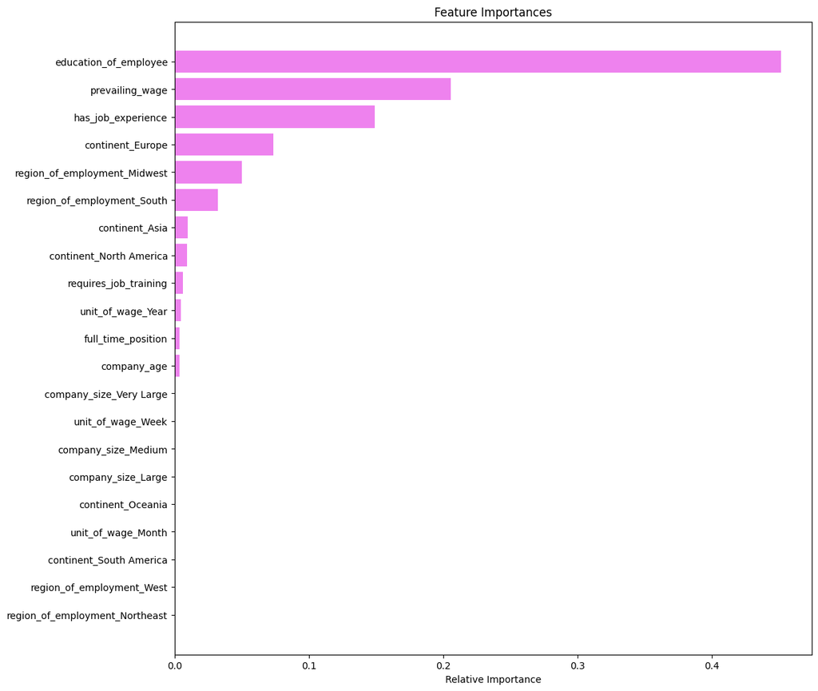

```python
# Observe the important features for the tuned model
show_feature_importances(dtree_tuned, x_train_over)
```

- Tuned decision tree is giving a much better F1 score on the validation dataset compared to the un-tuned decision tree with a difference of almost 8%
- We will use the tuned decision tree to compare the performance with other models
- Education is the most important feature identified by the decision tree model
- Prevailing wage and prior job experience are 2 other important features
- Region of employment and continent of the candidate also has some role to play

#### RandomForest model tuning

**Best practices for hyperparameter tuning in Random Forest:**

`n_estimators`:

- Start with a specific number (50 is used in general) and increase in steps: 50, 75, 100, 125
- Higher values generally improve performance but increase training time
- Use 100-150 for large datasets or when variance is high

`min_samples_leaf`:

- Try values like: 1, 2, 4, 5, 10
- Higher values reduce model complexity and help prevent overfitting
- Use 1–2 for low-bias models, higher (like 5 or 10) for more regularized models
- Works well in noisy datasets to smooth predictions

`max_features`:

- Try values: `"sqrt"` (default for classification), `"log2"`, `None`, or float values (e.g., `0.3`, `0.5`)
- `"sqrt"` balances between diversity and performance for classification tasks
- Lower values (e.g., `0.3`) increase tree diversity, reducing overfitting
- Higher values (closer to `1.0`) may capture more interactions but risk overfitting

`max_samples` (for bootstrap sampling):

- Try float values between `0.5` to `1.0` or fixed integers
- Use `0.6–0.9` to introduce randomness and reduce overfitting
- Smaller values increase diversity between trees, improving generalization

RandomForest model was giving slightly better performance using the model trained on the original data. Let's tune the RandomForest model by using the original training data

```python
# Initialize the model
rf_tuned = RandomForestClassifier(random_state=1)

# Define the parameters to identify the best model using RandomizedSearchCV
rcv_params = {"n_estimators": [50,75,100,125,150,175,200],
              "min_samples_leaf": np.arange(1, 11, 1),
              "max_features": np.arange(0.3, 0.9, 0.1),
              "max_samples": np.arange(0.3, 0.8, 0.1),
              "class_weight" : ['balanced', 'balanced_subsample', None],
              "max_depth": np.arange(2,16,2)
}

# Initialize the RandomizedSearchCV object while using F1 as the scoring method
# Use cv=5 to split the training data into 5 parts, and train and evaluate the model 5 times by using each part as validation set once each time
rcv = RandomizedSearchCV(rf_tuned, rcv_params, cv=5, n_iter=500, scoring=scorer, random_state=1, n_jobs=-1, verbose=2)
rcv.fit(x_train, y_train)
print(rcv.best_params_)

rf_tuned = rcv.best_estimator_
```

```
Fitting 5 folds for each of 500 candidates, totalling 2500 fits
{'n_estimators': 100, 'min_samples_leaf': np.int64(5), 'max_samples': np.float64(0.5), 'max_features': np.float64(0.3), 'max_depth': np.int64(6), 'class_weight': None}
```

```python
# Observe the performance on training dataset
rf_train_perf = model_performance_classification_sklearn(rf_tuned, x_train, y_train)
rf_train_perf.index = ['RandomForest']
rf_train_perf
```

|  | Accuracy | Recall | Precision | F1 |
| --- | --- | --- | --- | --- |
| RandomForest | 0.748532 | 0.911465 | 0.759907 | 0.828815 |

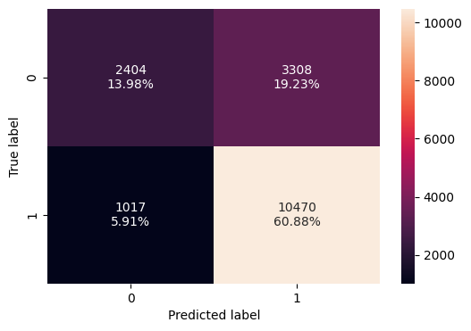

```python
# Plot the confusion matrix for the precitions on training dataset
confusion_matrix_sklearn(rf_tuned, x_train, y_train)
```

```python
# Observe the performance on validation dataset
rf_val_perf = model_performance_classification_sklearn(rf_tuned, x_val, y_val)
rf_val_perf.index = ['RandomForest']
rf_val_perf
```

|  | Accuracy | Recall | Precision | F1 |
| --- | --- | --- | --- | --- |
| RandomForest | 0.74359 | 0.906242 | 0.757477 | 0.825208 |

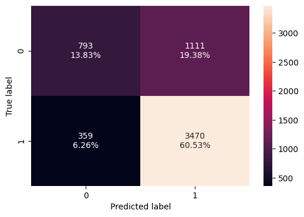

```python
# Plot the confusion matrix for the precitions on validation dataset
confusion_matrix_sklearn(rf_tuned, x_val, y_val)
```

```python
# Compare the performance of the un-tuned random forest model and the tuned random forest model on the validation data
test_perf = pd.concat(
    [
        model_original_data_val_perf.loc[['RandomForest']].T,
        rf_val_perf.T
    ],
    axis=1
)

test_perf.columns = ['RandomForest_Original', 'RandomForest_Tuned']

test_perf
```

|  | RandomForest_Original | RandomForest_Tuned |
| --- | --- | --- |
| Accuracy | 0.716204 | 0.743590 |
| Recall | 0.829982 | 0.906242 |
| Precision | 0.765046 | 0.757477 |
| F1 | 0.796192 | 0.825208 |

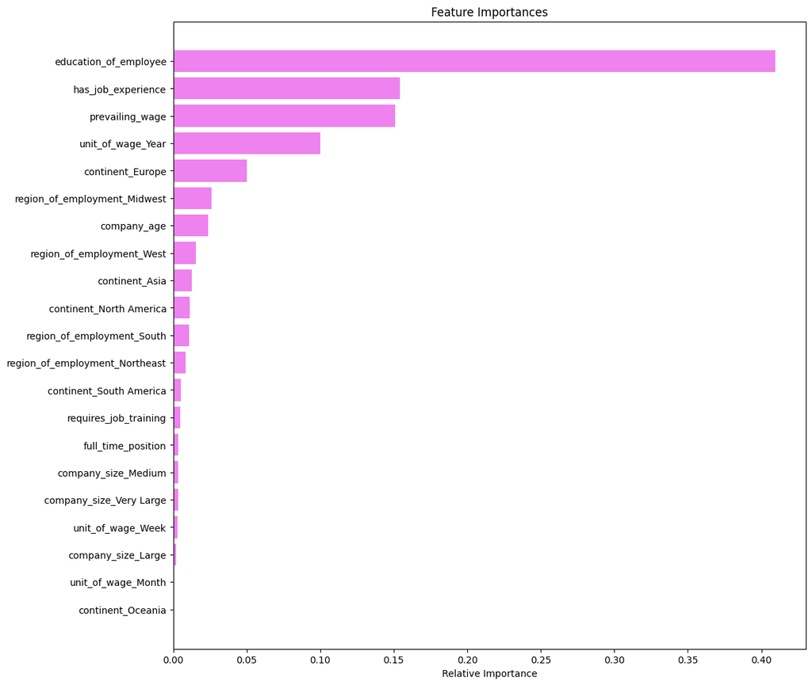

```python
# Observe the important features for the tuned model
show_feature_importances(rf_tuned, x_train)
```

- Tuned Random Forest model is giving a better F1 score on the validation dataset compared to the un-tuned model with a difference of almost 3%
- We will use the tuned Random Forest model to compare the performance with other models
- Education is the most important feature identified by the model
- Prior job experience and the prevailing wage are 2 other important features
- Unit of wage and continent of the candidate also has some role to play

#### AdaBoost model tuning

**Best practices for hyperparameter tuning in AdaBoost:**

`n_estimators`:

- Start with a specific number (50 is used in general) and increase in steps: 50, 75, 85, 100
- Use fewer estimators (e.g., 50 to 100) if using complex base learners (like deeper decision trees)
- Use more estimators (e.g., 100 to 150) when learning rate is low (e.g., 0.1 or lower)
- Avoid very high values unless performance keeps improving on validation

`learning_rate`:

- Common values to try: 1.0, 0.5, 0.1, 0.01
- Use 1.0 for faster training, suitable for fewer estimators
- Use 0.1 or 0.01 when using more estimators to improve generalization
- Avoid very small values (< 0.01) unless you plan to use many estimators (e.g., >500) and have sufficient data

AdaBoost model was giving slightly better performance using the model trained on the original data. Let's tune the AdaBoost model by using the original training data

```python
# Initialize the model
abc_tuned = AdaBoostClassifier(random_state=1)

# Define the parameters to identify the best model using RandomizedSearchCV
rcv_params = {
    "estimator":[DecisionTreeClassifier(max_depth=1, random_state=1), DecisionTreeClassifier(max_depth=2, random_state=1), DecisionTreeClassifier(max_depth=3, random_state=1), DecisionTreeClassifier(max_depth=4, random_state=1), DecisionTreeClassifier(max_depth=5, random_state=1), DecisionTreeClassifier(max_depth=6, random_state=1)],
    "n_estimators": np.arange(50,625,50),
    "learning_rate": [0.001, 0.005, 0.01, 0.05, 0.1, 0.2, 0.5, 0.7, 0.8, 1]
}

rcv = RandomizedSearchCV(abc_tuned, rcv_params, cv=5, n_iter=500, scoring=scorer, random_state=1, n_jobs=-1, verbose=2)
rcv.fit(x_train, y_train)
print(rcv.best_params_)

abc_tuned = rcv.best_estimator_
```

```
Fitting 5 folds for each of 500 candidates, totalling 2500 fits
{'n_estimators': np.int64(400), 'learning_rate': 0.01, 'estimator': DecisionTreeClassifier(max_depth=6, random_state=1)}
```

```python
# Observe the performance on training dataset
abc_train_perf = model_performance_classification_sklearn(abc_tuned, x_train, y_train)
abc_train_perf.index = ['AdaBoost']
abc_train_perf
```

|  | Accuracy | Recall | Precision | F1 |
| --- | --- | --- | --- | --- |
| AdaBoost | 0.755974 | 0.882128 | 0.780903 | 0.828435 |

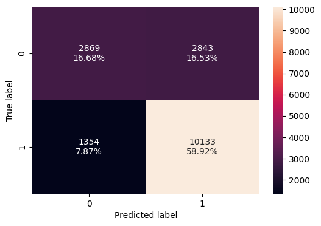

```python
# Plot the confusion matrix for the precitions on training dataset
confusion_matrix_sklearn(abc_tuned, x_train, y_train)
```

```python
# Observe the performance on validation dataset
abc_val_perf = model_performance_classification_sklearn(abc_tuned, x_val, y_val)
abc_val_perf.index = ['AdaBoost']
abc_val_perf
```

|  | Accuracy | Recall | Precision | F1 |
| --- | --- | --- | --- | --- |
| AdaBoost | 0.75266 | 0.877253 | 0.779893 | 0.825713 |

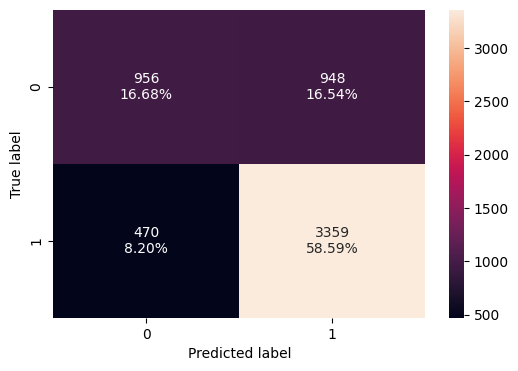

```python
# Plot the confusion matrix for the precitions on validation dataset
confusion_matrix_sklearn(abc_tuned, x_val, y_val)
```

```python
# Compare the performance of the un-tuned AdaBoost model and the tuned AdaBoost model on the validation data
test_perf = pd.concat(
    [
        model_original_data_val_perf.loc[['AdaBoost']].T,
        abc_val_perf.T
    ],
    axis=1
)

test_perf.columns = ['AdaBoost_Original', 'AdaBoost_Tuned']

test_perf
```

|  | AdaBoost_Original | AdaBoost_Tuned |
| --- | --- | --- |
| Accuracy | 0.739752 | 0.752660 |
| Recall | 0.881954 | 0.877253 |
| Precision | 0.764546 | 0.779893 |
| F1 | 0.819064 | 0.825713 |

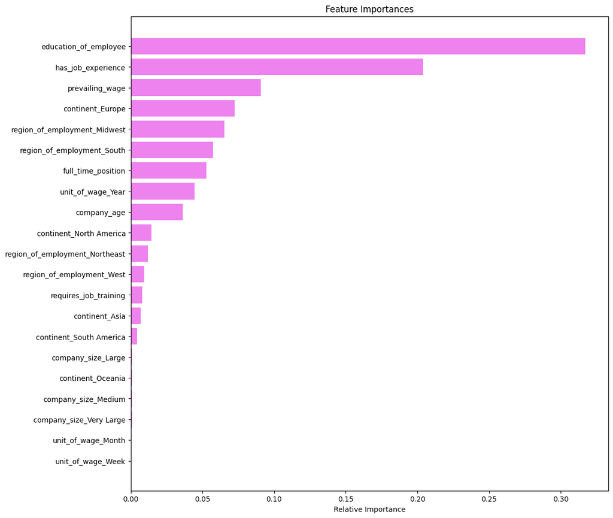

```python
# Observe the important features for the tuned model
show_feature_importances(abc_tuned, x_train)
```

- Tuned AdaBoost model is giving slighly better performance on the F1 score on the validation dataset compared to the un-tuned AdaBoost model with a difference of about 0.7%
- We will use the tuned AdaBoost model to compare the performance with other models
- Education is the most important feature identified by the model
- Prior job experience is the next important feature
- Region of employment, full time position, prevailing wage and continent of the candidate are some other features that contribute to the model

#### GradientBoost model tuning

**Best practices for hyperparameter tuning in Gradient Boosting:**

`n_estimators`:

- Start with 100 (default) and increase: 100, 200, 300, 500
- Typically, higher values lead to better performance, but they also increase training time
- Use 200–500 for larger datasets or complex problems
- Monitor validation performance to avoid overfitting, as too many estimators can degrade generalization

`learning_rate`:

- Common values to try: 0.1, 0.05, 0.01, 0.005
- Use lower values (e.g., 0.01 or 0.005) if you are using many estimators (e.g., > 200)
- Higher learning rates (e.g., 0.1) can be used with fewer estimators for faster convergence
- Always balance the learning rate with `n_estimators` to prevent overfitting or underfitting

`subsample`:

- Common values: 0.7, 0.8, 0.9, 1.0
- Use a value between `0.7` and `0.9` for improved generalization by introducing randomness
- `1.0` uses the full dataset for each boosting round, potentially leading to overfitting
- Reducing `subsample` can help reduce overfitting, especially in smaller datasets

`max_features`:

- Common values: `"sqrt"`, `"log2"`, or float (e.g., `0.3`, `0.5`)
- `"sqrt"` (default) works well for classification tasks
- Lower values (e.g., `0.3`) help reduce overfitting by limiting the number of features considered at each split

GradientBoost model was giving slightly better performance using the model trained on original data. Let's tune the GradientBoost model using the original training data

```python
# Initialize the model
gb_tuned = GradientBoostingClassifier(init=AdaBoostClassifier(random_state=1), random_state=1)

# Define the parameter to identify the best model using RandomizedSearchCV
rcv_params = {"n_estimators": [50, 100, 150, 200, 250, 300, 350, 400],
              "learning_rate": [0.001, 0.005, 0.01, 0.05, 0.1, 0.2, 0.5, 0.7, 0.8, 1] ,
              "subsample": [0.5, 0.6, 0.7, 0.8, 1],
              "max_features": [0.3, 0.4, 0.5, 0.6, 0.7, 0.8]
}

# Initialize the RandomizedSearchCV object while using F1 as the scoring method
# Use cv=5 to split the training data into 5 parts, and train and evaluate the model 5 times by using each part as validation set once each time
rcv = RandomizedSearchCV(gb_tuned, rcv_params, cv=5, n_iter=250, scoring=scorer, random_state=1, n_jobs=-1, verbose=2)
rcv.fit(x_train, y_train)
print(rcv.best_params_)

gb_tuned = rcv.best_estimator_
```

```
Fitting 5 folds for each of 250 candidates, totalling 1250 fits
{'subsample': 0.8, 'n_estimators': 50, 'max_features': 0.7, 'learning_rate': 0.1}
```

```python
# Observe the performance on training dataset
gb_train_perf = model_performance_classification_sklearn(gb_tuned, x_train, y_train)
gb_train_perf.index = ['GradientBoost']
gb_train_perf
```

|  | Accuracy | Recall | Precision | F1 |
| --- | --- | --- | --- | --- |
| GradientBoost | 0.75173 | 0.879516 | 0.777812 | 0.825543 |

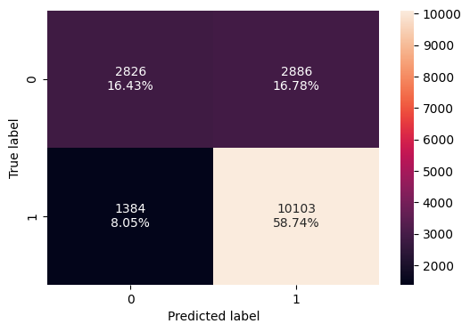

```python
# Plot the confusion matrix for the precitions on training dataset
confusion_matrix_sklearn(gb_tuned, x_train, y_train)
```

```python
# Observe the performance on validation dataset
gb_val_perf = model_performance_classification_sklearn(gb_tuned, x_val, y_val)
gb_val_perf.index = ['GradientBoost']
gb_val_perf
```

|  | Accuracy | Recall | Precision | F1 |
| --- | --- | --- | --- | --- |
| GradientBoost | 0.751265 | 0.876991 | 0.778576 | 0.824859 |

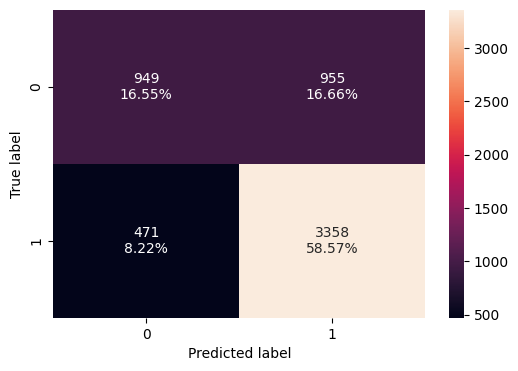

```python
# Plot the confusion matrix for the precitions on validation dataset
confusion_matrix_sklearn(gb_tuned, x_val, y_val)
```

```python
# Compare the performance of the un-tuned AdaBoost model and the tuned AdaBoost model on the validation data
test_perf = pd.concat(
    [
        model_original_data_val_perf.loc[['GradientBoost']].T,
        gb_val_perf.T
    ],
    axis=1
)

test_perf.columns = ['GradientBoost_Original', 'GradientBoost_Tuned']

test_perf
```

|  | GradientBoost_Original | GradientBoost_Tuned |
| --- | --- | --- |
| Accuracy | 0.750044 | 0.751265 |
| Recall | 0.872552 | 0.876991 |
| Precision | 0.779515 | 0.778576 |
| F1 | 0.823413 | 0.824859 |

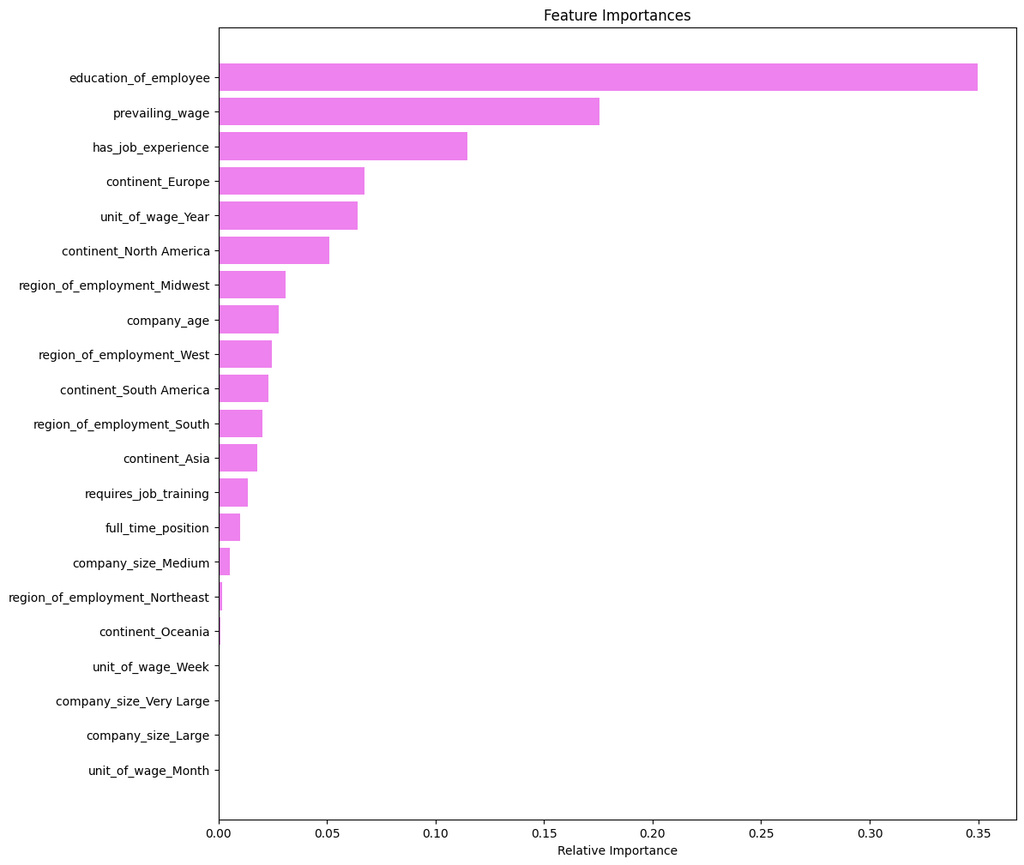

```python
# Observe the important features for the tuned model
show_feature_importances(gb_tuned, x_train)
```

- F1 scores for both the tuned and un-tuned GradientBoost models are almost same, with the score for the tuned model only slightly better
- We will use the tuned model to compare the performance with other models
- Education is the most important feature identified by the decision tree model
- Prevailing wage and prior job experience are the next important features
- Unit of wage, continent of the candidate and region of employment are some other features that contribute to the model

#### XGBoost model tuning

**Best practices for hyperparameter tuning in XGBoost:**

`n_estimators`:

- Start with 50 and increase in steps: 50,75,100,125.
- Use more estimators (e.g., 150-250) when using lower learning rates
- Monitor validation performance
- High values improve learning but increase training time

`subsample`:

- Common values: 0.5, 0.7, 0.8, 1.0
- Use `0.7–0.9` to introduce randomness and reduce overfitting
- `1.0` uses the full dataset in each boosting round; may overfit on small datasets
- Values < 0.5 are rarely useful unless dataset is very large

`gamma`:

- Try values: 0 (default), 1, 3, 5, 8
- Controls minimum loss reduction needed for a split
- Higher values make the algorithm more conservative (i.e., fewer splits)
- Use values > 0 to regularize and reduce overfitting, especially on noisy data

`colsample_bytree`:

- Try values: 0.3, 0.5, 0.7, 1.0
- Fraction of features sampled per tree
- Lower values (e.g., 0.3 or 0.5) increase randomness and improve generalization
- Use `1.0` when you want all features considered for every tree

`colsample_bylevel`:

- Try values: 0.3, 0.5, 0.7, 1.0
- Fraction of features sampled at each tree level (i.e., per split depth)
- Lower values help in regularization and reducing overfitting
- Often used in combination with `colsample_bytree` for fine control over feature sampling

XGBoost model was giving slightly better performance using the model trained on oversampled data. Let's tune the XGBoost model using the oversampled training data

```python
# Initialize the model
xgb_tuned = XGBClassifier(random_state=1)

# Define the parameters to identify the best model using RandomizedSearchCV
parameters = {
    "n_estimators": np.arange(25,301,25),
    "scale_pos_weight":[0,1,2,3,4,5],
    "subsample":[0.3, 0.4, 0.5, 0.6, 0.7, 1],
    "learning_rate":[0.001, 0.005, 0.01, 0.05, 0.1, 0.2],
    "gamma":[0,1,2,3],
    "colsample_bytree":[0.3, 0.4, 0.5, 0.6, 0.7],
    "colsample_bylevel":[0.3, 0.4, 0.5, 0.6, 0.7]
}


# Initialize the RandomizedSearchCV object while using F1 as the scoring method
# Use cv=5 to split the training data into 5 parts, and train and evaluate the model 5 times by using each part as validation set once each time
rcv = RandomizedSearchCV(xgb_tuned, parameters, n_iter=800, scoring=scorer, cv=5, n_jobs=-1, random_state=1, verbose=2)
rcv.fit(x_train_over, y_train_over)

xgb_tuned = rcv.best_estimator_

print(rcv.best_params_)
```

```
Fitting 5 folds for each of 800 candidates, totalling 4000 fits
{'subsample': 1, 'scale_pos_weight': 2, 'n_estimators': np.int64(175), 'learning_rate': 0.1, 'gamma': 0, 'colsample_bytree': 0.5, 'colsample_bylevel': 0.5}
```

```python
# Observe the performance on training dataset
xgb_train_perf = model_performance_classification_sklearn(xgb_tuned, x_train_over, y_train_over)
xgb_train_perf.index = ['XGBoost']
xgb_train_perf
```

|  | Accuracy | Recall | Precision | F1 |
| --- | --- | --- | --- | --- |
| XGBoost | 0.784555 | 0.966745 | 0.743804 | 0.840746 |

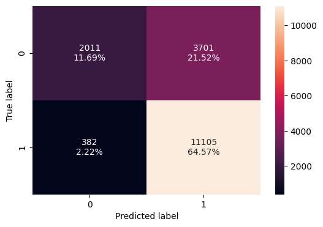

```python
# Plot the confusion matrix for the precitions on training dataset
confusion_matrix_sklearn(xgb_tuned, x_train, y_train)
```

```python
# Observe the performance on validation dataset
xgb_val_perf = model_performance_classification_sklearn(xgb_tuned, x_val, y_val)
xgb_val_perf.index = ['XGBoost']
xgb_val_perf
```

|  | Accuracy | Recall | Precision | F1 |
| --- | --- | --- | --- | --- |
| XGBoost | 0.721612 | 0.936798 | 0.725966 | 0.818016 |

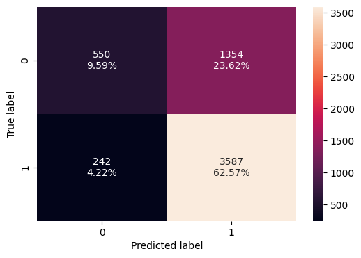

```python
# Plot the confusion matrix for the precitions on validation dataset
confusion_matrix_sklearn(xgb_tuned, x_val, y_val)
```

```python
# Compare the performance of the un-tuned AdaBoost model and the tuned AdaBoost model on the validation data
test_perf = pd.concat(
    [
        model_oversample_data_val_perf.loc[['XGBoost']].T,
        xgb_val_perf.T
    ],
    axis=1
)

test_perf.columns = ['XGBoost_Original', 'XGBoost_Tuned']

test_perf
```

|  | XGBoost_Original | XGBoost_Tuned |
| --- | --- | --- |
| Accuracy | 0.742194 | 0.721612 |
| Recall | 0.857665 | 0.936798 |
| Precision | 0.778753 | 0.725966 |
| F1 | 0.816306 | 0.818016 |

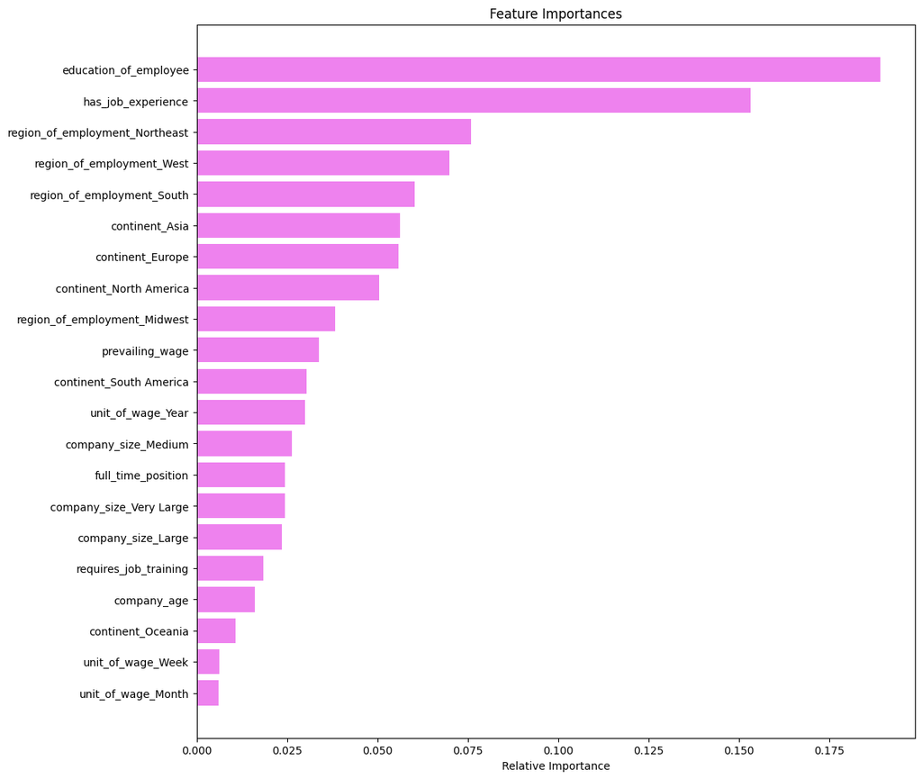

```python
# Observe the important feature for the tuned model
show_feature_importances(xgb_tuned, x_train_over)
```

- Tuned XGBoost model is giving slighly better F1 score on the validation dataset compared to the un-tuned XGBoost model
- We will use the tuned model to compare the performance with other models
- Education is the most important feature identified by the decision tree model
- Prior job experience and Region of employment are the next important features
- Continent of the candidate also has some role to play

#### Stacking Classifier

Let's create a stacking classifier model by using the tuned Random Forest, Decision Tree and Ada Boost models as estimator, and the tuned GradientBoost model as the final estimator

```python
# Create a stacking classifier model using the tuned versions of Random Forest, Decision Tree and AdaBoost models
estimators = [('RandomForest', rf_tuned), ('DecisionTree', dtree_tuned), ('AdaBoost', abc_tuned)]

# Use GradientBoost model as the final estimator
final_estimator = gb_tuned

stacking_classifier = StackingClassifier(estimators=estimators, final_estimator=final_estimator)

stacking_classifier.fit(x_train,y_train)
```

```
StackingClassifier(estimators=[('RandomForest',
                                RandomForestClassifier(max_depth=np.int64(6),
                                                       max_features=np.float64(0.3),
                                                       max_samples=np.float64(0.5),
                                                       min_samples_leaf=np.int64(5),
                                                       random_state=1)),
                               ('DecisionTree',
                                DecisionTreeClassifier(max_depth=np.int64(7),
                                                       max_leaf_nodes=25,
                                                       min_samples_split=5,
                                                       random_state=1)),
                               ('AdaBoost',
                                AdaBoostClassifier(estimator=DecisionTreeClassifier(max_depth=6,
                                                                                    random_state=1),
                                                   learning_rate=0.01,
                                                   n_estimators=np.int64(400),
                                                   random_state=1))],
                   final_estimator=GradientBoostingClassifier(init=AdaBoostClassifier(random_state=1),
                                                              max_features=0.7,
                                                              n_estimators=50,
                                                              random_state=1,
                                                              subsample=0.8))
```

```python
# Observe the performance on training dataset
stack_train_perf = model_performance_classification_sklearn(stacking_classifier, x_train, y_train)
stack_train_perf.index = ['Stacking']
stack_train_perf
```

|  | Accuracy | Recall | Precision | F1 |
| --- | --- | --- | --- | --- |
| Stacking | 0.755276 | 0.867502 | 0.787623 | 0.825635 |

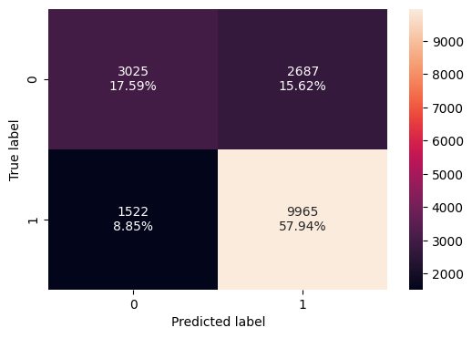

```python
# Plot the confusion matrix for the precitions on training dataset
confusion_matrix_sklearn(stacking_classifier, x_train, y_train)
```

```python
# Observe the performance on validation dataset
stack_val_perf = model_performance_classification_sklearn(stacking_classifier, x_val, y_val)
stack_val_perf.index = ['Stacking']
stack_val_perf
```

|  | Accuracy | Recall | Precision | F1 |
| --- | --- | --- | --- | --- |
| Stacking | 0.75109 | 0.86315 | 0.785409 | 0.822446 |

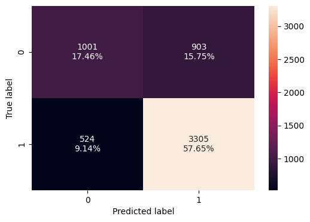

```python
# Plot the confusion matrix for the precitions on validation dataset
confusion_matrix_sklearn(stacking_classifier, x_val, y_val)
```

Stacking model is generalizing well on the training and validation datasets

## Model Performance Summary and Final Model Selection

- All the tuned models fared better in comparison to the base models
- Let's compare the performance of all the tuned models on the training dataset

```python
# Get the performance scores of all the tuned models on the training dataset
train_perf = pd.concat(
    [
        dtree_train_perf.T,
        rf_train_perf.T,
        abc_train_perf.T,
        gb_train_perf.T,
        xgb_train_perf.T,
        stack_train_perf.T
    ],
    axis=1
)

train_perf
```

|  | DTree | RandomForest | AdaBoost | GradientBoost | XGBoost | Stacking |
| --- | --- | --- | --- | --- | --- | --- |
| Accuracy | 0.750974 | 0.748532 | 0.755974 | 0.751730 | 0.784555 | 0.755276 |
| Recall | 0.875773 | 0.911465 | 0.882128 | 0.879516 | 0.966745 | 0.867502 |
| Precision | 0.778879 | 0.759907 | 0.780903 | 0.777812 | 0.743804 | 0.787623 |
| F1 | 0.824489 | 0.828815 | 0.828435 | 0.825543 | 0.840746 | 0.825635 |

```python
# Get the performance scores of all the tuned models on the validation dataset

val_perf = pd.concat(
    [
        dtree_val_perf.T,
        rf_val_perf.T,
        abc_val_perf.T,
        gb_val_perf.T,
        xgb_val_perf.T,
        stack_val_perf.T
    ],
    axis=1
)

val_perf
```

|  | DTree | RandomForest | AdaBoost | GradientBoost | XGBoost | Stacking |
| --- | --- | --- | --- | --- | --- | --- |
| Accuracy | 0.750916 | 0.743590 | 0.752660 | 0.751265 | 0.721612 | 0.751090 |
| Recall | 0.873335 | 0.906242 | 0.877253 | 0.876991 | 0.936798 | 0.863150 |
| Precision | 0.780033 | 0.757477 | 0.779893 | 0.778576 | 0.725966 | 0.785409 |
| F1 | 0.824051 | 0.825208 | 0.825713 | 0.824859 | 0.818016 | 0.822446 |

- Decision Tree, Random Forest, AdaBoost, GradientBoost and Stacking models have almost same F1 score on the training dataset in the range of about 82.4% - 82.9%
- Decision Tree, Random Forest, AdaBoost, GradientBoost and Stacking models have almost same F1 score on the validation dataset in the range of about 82.2% - 82.6%
- All the above 5 models appear to be generalizing well
- Tuned XGBoost model appears to be slightly overfitting compared to the other models
- AdaBoost and RandomForest models have the best F1 score on validation dataset out of all the models, and have almost similar scores on the training dataset as well
- We will choose tuned AdaBoost as our final model, as it has slightly better accuracy than the GradientBoost model

**Let's check the performance of the tuned AdaBoost model on the test dataset**

```python
# Observe the performance on test dataset
abc_test_perf = model_performance_classification_sklearn(abc_tuned, x_test, y_test)
abc_test_perf
```

|  | Accuracy | Recall | Precision | F1 |
| --- | --- | --- | --- | --- |
| 0 | 0.745683 | 0.880729 | 0.771091 | 0.822271 |

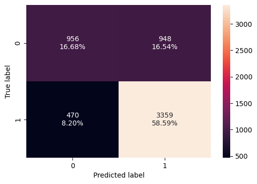

```python
# Plot the confusion matrix for the precitions on validation dataset
confusion_matrix_sklearn(abc_tuned, x_val, y_val)
```

- F1 score of the tune AdaBoost model on the test dataset is very close to the F1 score of the model on the training and validation datasets and it is not overfitting
- Tuned AdaBoost model is generalizing well on the training, validation and test datasets

## Actionable Insights and Recommendations

### Insights

- Number of applications certified is at about 67%
- Asia has the highest percentage of visa applications, at about 66% out of all the continents
  - Candidates from Europe had the highest certification rate at about 79%
  - Candidates from Africa had certification rate of about 72%
  - Candidates from Asia had certification rate of about 65%
  - Candidates from South America had the least certification rate of about 58%
- About 42% of the applicants have no prior job experience
  - Having a prior work experience enhanced the chances of visa approval, with about 74% of the applications certified for candidates having prior work experience
- Northeast region has the maximum percentage of visa applications at abouf 28%, closely followed by South region at about 27.5%
  - Visa certification were the highest for Midwest region at about 75.5%
  - Visa certifications were the lowest for Island region at about 60%
- About 90% of visa applications had unit of wage as year
  - Certification rate for applications with hourly unit of wage was low at about 35%
  - Certification rate for applications with yearly unit of wage was highest at about 70%
  - For cases with hourly, weekly and monthly units of wage, certified cases had higher wages compared to wages in the cases that were denied
- About 89% of the applications are for full time position
  - About 68.5% of the applications for a part time position were certified
  - About 66.5% of the applications for a full time position were certified
- 40% of the applicants had bachelor's degree, followed by applicants with Master's degree at about 38%
  - Higher education enhanced the chances of visa certification
  - About 87% certification rate for candidates having Doctorate
  - About 79% certification rate for candidates having Master's degree
  - About 62% certification rate for candidates having Bachelor's degree
  - Only 34% certification rate was observed for candidates having only High School education

Factors contributing the most towards certification of visa:

- Education level of the employee is the most important feature for the certification of visa, with higher chances of certification with higher level of education
- Having a prior job experience also impacts visa certification, with having a prior job experience is likely to certify a visa
- Employment region, full time position, prevailing wage and continent of the candidate also play a role in certification of visa

**The profile of the applicants for whom the visa could be approved, the best fit profile would be:**

- Eduction level - Higher the level of education, better the chance for approval. Master's and Doctorate are preferred most
- Job Experience - Should have a prior job experience

Secondary information to verify:

- Region of employment - Midwest and South regions have the most approvals
- Continent - Candidates from Europe and Africa appear to be more qualified

**The profile of the applicants for whom the visa could be deined:**

- Education level - Completed only high school and doesn't have any degree
- Job experience - No prior job experience

Secondary information to verify:

- Unit of wage - Hourly unit of wage
- Continent - Candidates from South America, North America and Oceania appear to be less qualified

### Recommendations:

- Tuned AdaBoost model is recommended to the OFLC as the final model to be used for predictions
- OFLC should condifer the applicant's level of education and job experience to identify potential candidates for Visa approval
- Although the models are generalizing well, the overall performance of the models has scope of improvement.
- Some other potentially important variables should also be considered in the model development, like category of the visa, industry of employment, name of the company, etc

Power Ahead